# Data 501

2026-03-10

#————————————–This file contains our inital EDA, as well as our analysis for RQ1——————-

#load in the CSV file and turn into a dataframe

#library we are using to create the histograms!

```r
library(ggplot2)
```

#histogram for the aggregate ESG score!

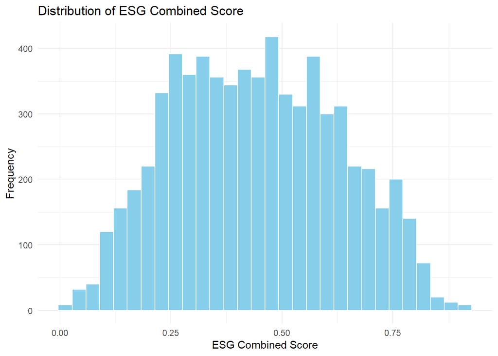

```r
# Histogram for ESG Combined Score
ggplot(d501, aes(x = ESGCombinedScore)) +
  geom_histogram(fill = "skyblue", color = "white", bins = 30, na.rm = TRUE) +
  labs(title = "Distribution of ESG Combined Score",
       x = "ESG Combined Score",
       y = "Frequency") +
  theme_minimal()
```

#Inital Histograms for SP Volatility and ESG Momentum (before transformation)

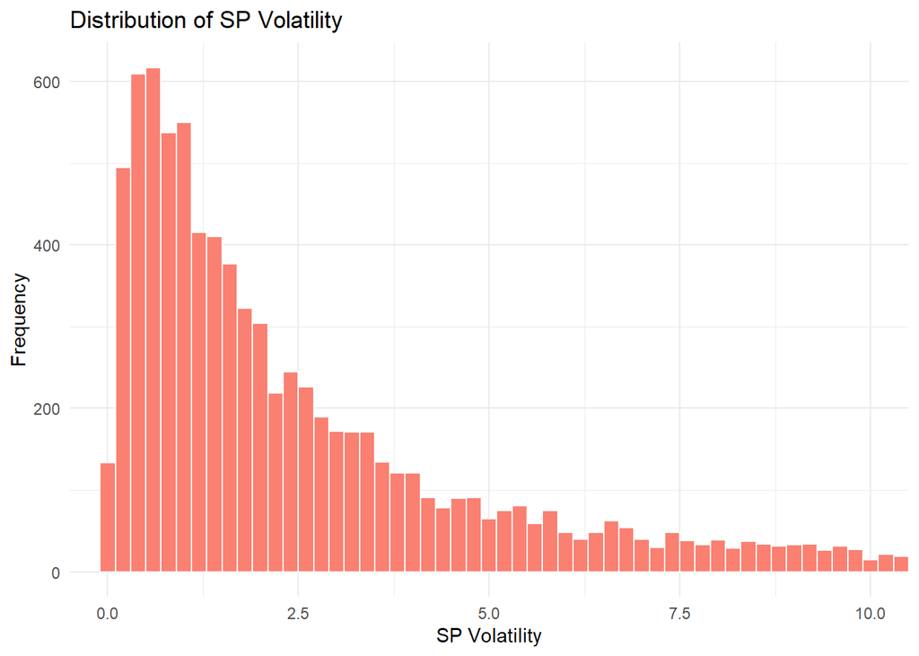

```r
ggplot(d501, aes(x = `SP.Volatility`)) +
  geom_histogram(fill = "salmon", color = "white", binwidth = 0.2, na.rm = TRUE) +
  coord_cartesian(xlim = c(0, 10)) +
  labs(title = "Distribution of SP Volatility",
       x = "SP Volatility",
       y = "Frequency") +
  theme_minimal()
```

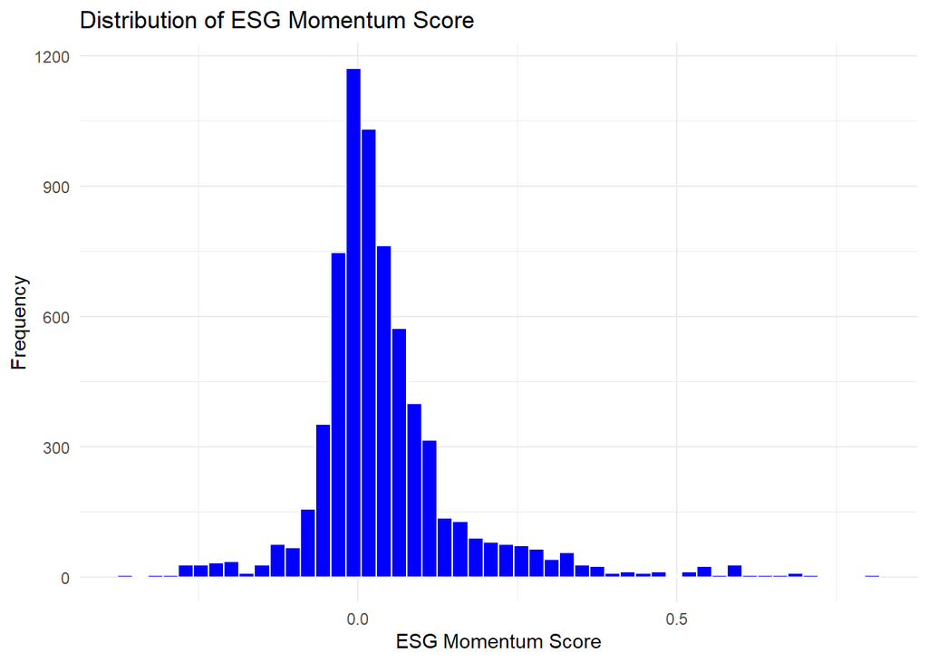

```r
# Histogram for ESG Momentum
ggplot(d501, aes(x = ESG.Momentum)) +
  geom_histogram(fill = "blue", color = "white", bins = 50, na.rm = TRUE) +
  labs(title = "Distribution of ESG Momentum Score",
       x = "ESG Momentum Score",
       y = "Frequency") +
  theme_minimal()
```

#Inital histograms for ESG momentum pillars (before transformation)!

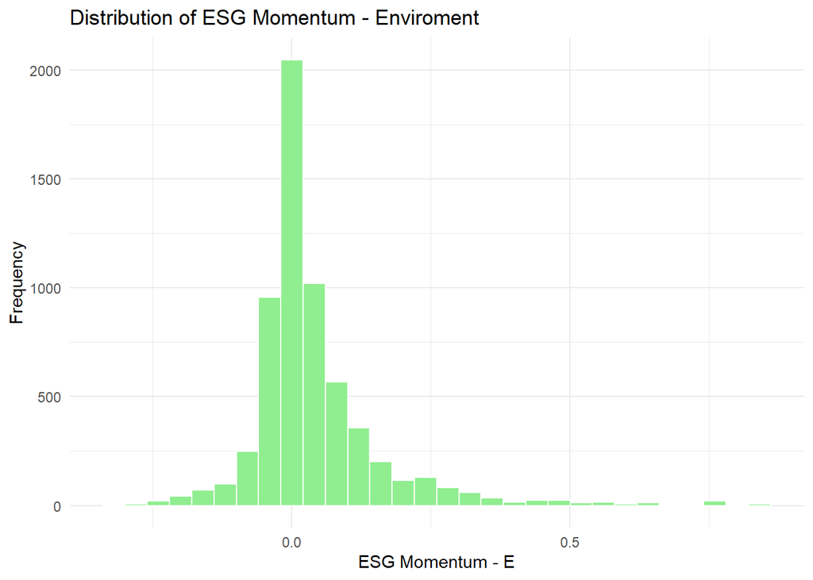

```r
ggplot(d501, aes(x = ESG.Mom.Env)) +
  geom_histogram(fill = "lightgreen", color = "white", bins = 30, na.rm = TRUE) +
  labs(title = "Distribution of ESG Momentum - Enviroment",
       x = "ESG Momentum - E",
       y = "Frequency") +
  theme_minimal()
```

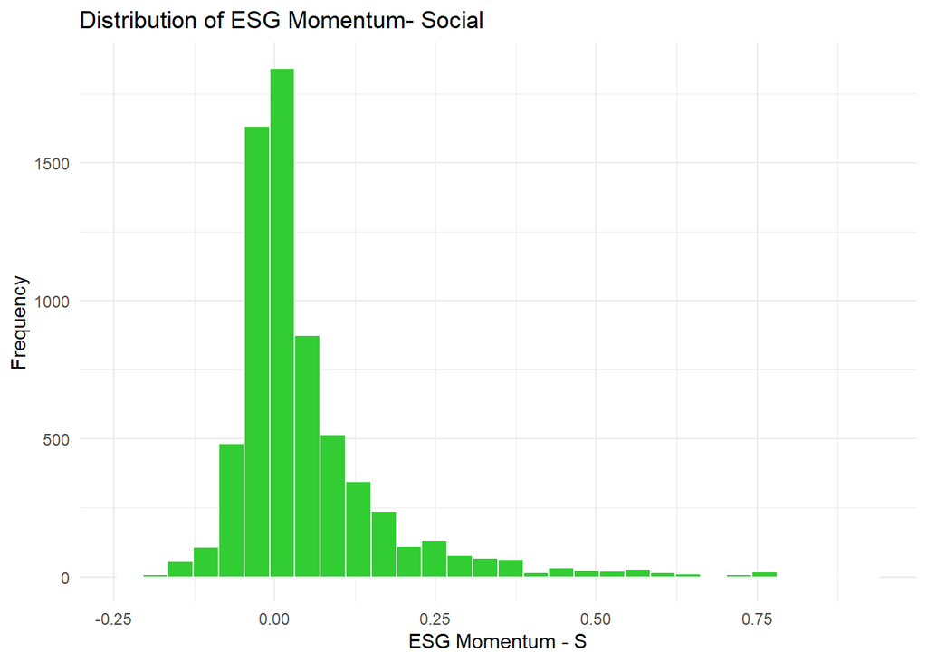

```r
ggplot(d501, aes(x = ESG.Mom...Social)) +
  geom_histogram(fill = "limegreen", color = "white", bins = 30, SSna.rm = TRUE) +
  labs(title = "Distribution of ESG Momentum- Social",
       x = "ESG Momentum - S",
       y = "Frequency") +
  theme_minimal()
```

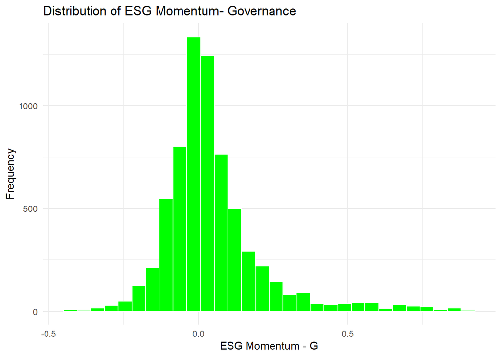

```r
ggplot(d501, aes(x = ESG.Mom...Gov)) +
  geom_histogram(fill = "green", color = "white", bins = 30, na.rm = TRUE) +
  labs(title = "Distribution of ESG Momentum- Governance",
       x = "ESG Momentum - G",
       y = "Frequency") +
  theme_minimal()
```

#QQplot for ESG Momentum and SP volatility before transformation

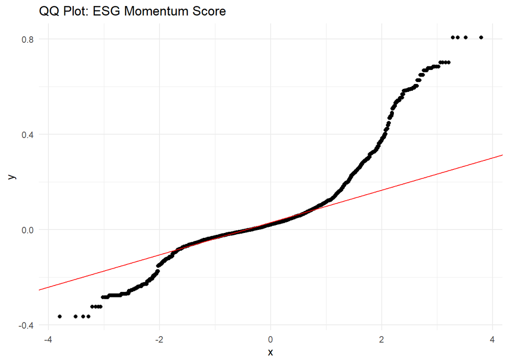

```r
ggplot(d501, aes(sample = ESG.Momentum)) +
  stat_qq(na.rm = TRUE) +
  stat_qq_line(color = "red", na.rm = TRUE) +
  labs(title = "QQ Plot: ESG Momentum Score") +
  theme_minimal()
```

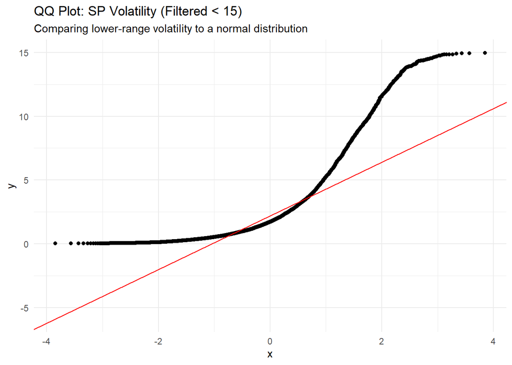

```r
# Filtering to < 15 to make the QQ plot readable
vol_filtered <- subset(d501, `SP.Volatility` < 15)

ggplot(vol_filtered, aes(sample = `SP.Volatility`)) +
  stat_qq(na.rm = TRUE) +
  stat_qq_line(color = "red", na.rm = TRUE) +
  labs(title = "QQ Plot: SP Volatility (Filtered < 15)",
       subtitle = "Comparing lower-range volatility to a normal distribution") +
  theme_minimal()
```

#QQplot for ESG pillars before transformation

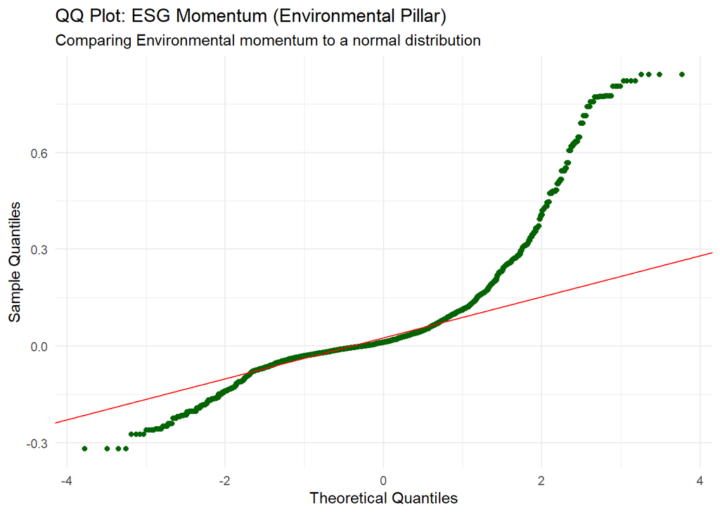

```r
ggplot(d501, aes(sample = `ESG.Mom.Env`)) +
  stat_qq(na.rm = TRUE, color = "darkgreen") +
  stat_qq_line(color = "red", na.rm = TRUE) +
  labs(title = "QQ Plot: ESG Momentum (Environmental Pillar)",
       subtitle = "Comparing Environmental momentum to a normal distribution",
       x = "Theoretical Quantiles",
       y = "Sample Quantiles") +
  theme_minimal()
```

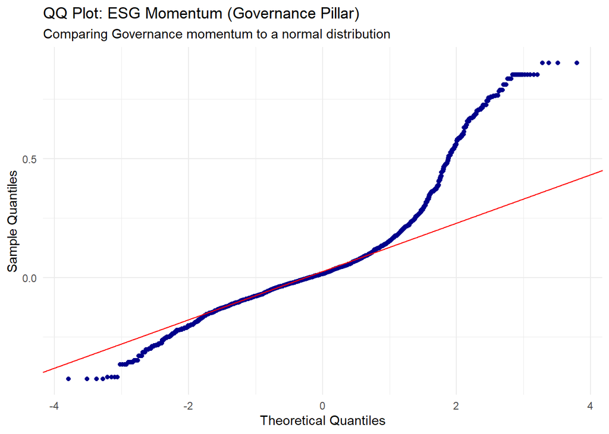

```r
ggplot(d501, aes(sample = `ESG.Mom...Gov`)) +
  stat_qq(na.rm = TRUE, color = "darkblue") +
  stat_qq_line(color = "red", na.rm = TRUE) +
  labs(title = "QQ Plot: ESG Momentum (Governance Pillar)",
       subtitle = "Comparing Governance momentum to a normal distribution",
       x = "Theoretical Quantiles",
       y = "Sample Quantiles") +
  theme_minimal()
```

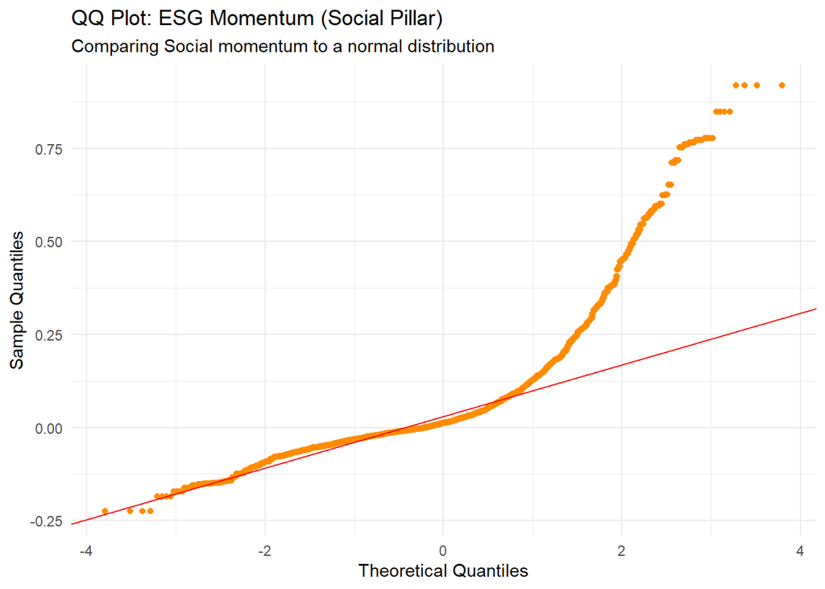

```r
ggplot(d501, aes(sample = `ESG.Mom...Social`)) +
  stat_qq(na.rm = TRUE, color = "darkorange") +
  stat_qq_line(color = "red", na.rm = TRUE) +
  labs(title = "QQ Plot: ESG Momentum (Social Pillar)",
       subtitle = "Comparing Social momentum to a normal distribution",
       x = "Theoretical Quantiles",
       y = "Sample Quantiles") +
  theme_minimal()
```

#The following plot looks at the relationship of ESG momentum and SP volatility before transformation

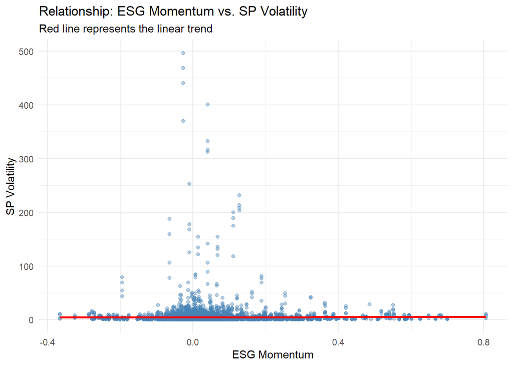

```r
ggplot(d501, aes(x = `ESG.Momentum`, y = `SP.Volatility`)) +
  geom_point(alpha = 0.4, color = "steelblue") +
  geom_smooth(method = "lm", color = "red", se = TRUE) + # Adds linear regression line
  labs(title = "Relationship: ESG Momentum vs. SP Volatility",
       subtitle = "Red line represents the linear trend",
       x = "ESG Momentum",
       y = "SP Volatility") +
  theme_minimal()
```

#red line here represents the relationship between SP volatility and ESG momentum,the fact that it is flat is very bad! #our data shows a non-normal pattern, dots curve upwards away from the red line, means we have extreme positives (fat right tails, we expected this) #The plot above is the last thing I included in the shared doc!! Everything after this needs to be written about in our proposal!

#running aderson darling test for normality!

```r
library(nortest)
ad.test(d501$SP.Volatility)
```

```
##
##  Anderson-Darling normality test
##
## data:  d501$SP.Volatility
## A = 2049.7, p-value < 2.2e-16
```

#WINSORIZING THE DATA #benefits of this: manage outliers by replacing extreme values with the next nearest values within a specific percentile range (e.g., capping the top and bottom 1% or 5% of data points). Unlike removing outliers (trimming), Winsorization keeps the total number of observations, which preserves statistical power and ensures the sample size remains constant

#library we are using for winsorizition is DescTools

```r
#install.packages("DescTools") install this package if you dont already have it!
library(DescTools)
```

#staring with SP volatility, I will take the natural log before winsorizing #Stock price volatility is log-normally distributed. This means you have a massive “clump” of low-volatility days and a “long tail” of extreme high-volatility days (crises, earnings misses, etc.) When you take the Log, you “pull” that long right-tail toward the center and “stretch” the clump. makes the distribution look like a normal distribution #This sequence ensures that outliers are identified and mitigated within a symmetric distribution, preventing the loss of economically significant variations in the right-tail of the raw volatility data.

```r
# Create Log Volatility (adding a tiny amount if there are zeros, though rare in vol), adds a column to our dataframe called log_vol!
d501$log_vol <- log(d501$SP.Volatility + 1)
```

```r
# Winsorize the Log Volatility at 1% and 99%
d501$wins_log_vol <- DescTools::Winsorize(d501$log_vol, val = quantile(x = d501$log_vol, probs = c(0.01, 0.99), na.rm = TRUE))

# Winsorize the ESG Momentum! dont need to take the log first for this one, winsorizing at 0.5% and 99.5% to remove truly impossible data points while stil being conservative!
d501$wins_esg_mom <- DescTools::Winsorize(d501$ESG.Momentum, val = quantile(x= d501$ESG.Momentum, probs = c(0.005, 0.995), na.rm = TRUE))
```

#making sure this worked

```r
#install.packages("mosaic") install this package if you dont already have it
library(mosaic)
favstats(~SP.Volatility, data=d501) #checking the means of these variable to see if winsorization worked!!
```

```
##         min        Q1   median       Q3      max     mean       sd    n missing
##  0.01122687 0.8189029 1.843431 4.113627 496.0957 4.844653 16.94447 8726      36
```

```r
favstats(~wins_log_vol, data=d501)
```

```
##         min        Q1   median       Q3      max     mean       sd    n missing
##  0.07913002 0.5982335 1.045011 1.631909 3.881255 1.200968 0.792807 8726      36
```

#worked!! the max and median values are way different now! The raw S&P volatility data exhibited extreme right-skewness and leptokurtosis, with a maximum value (496.09) exceeding the mean (4.84) by a factor of 100. unsuitable for linear regression as it violates the assumption of normality and risks outlier-driven results. Following a natural log transformation and winsorization, the mean (1.20) and median (1.04) were successfully aligned, and the standard deviation was reduced from 16.94 to 0.79. This normalization ensures that the subsequent panel regression estimates are robust and not unduly influenced by idiosyncratic volatility spikes.

#re-running the QQplot for ESG Momentum after it has been winsorizied

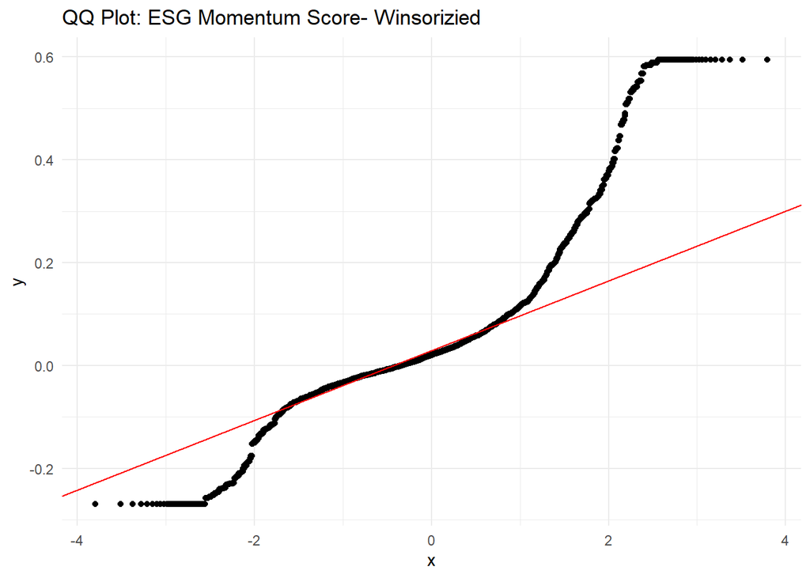

```r
library(ggplot2)
ggplot(d501, aes(sample = wins_esg_mom)) +
  stat_qq(na.rm = TRUE) +
  stat_qq_line(color = "red", na.rm = TRUE) +
  labs(title = "QQ Plot: ESG Momentum Score- Winsorizied") +
  theme_minimal()
```

#as we can see, the tails still curve away aggressively, should do something else too to try and linearize the data. Will still run SP volatility QQplot first to see how that changed things

#For ESG momentum, we should not take the log before winsorizing ESG momentum because ESG momentum is the change score, which means unlike SP volatility it can be negative, cannot take the log of a negative number. logging a small decimal like 0.01 creates large negative numbers which can actually increase the skewness?

#looking at how our transformation for SP volatility has affected the data below:

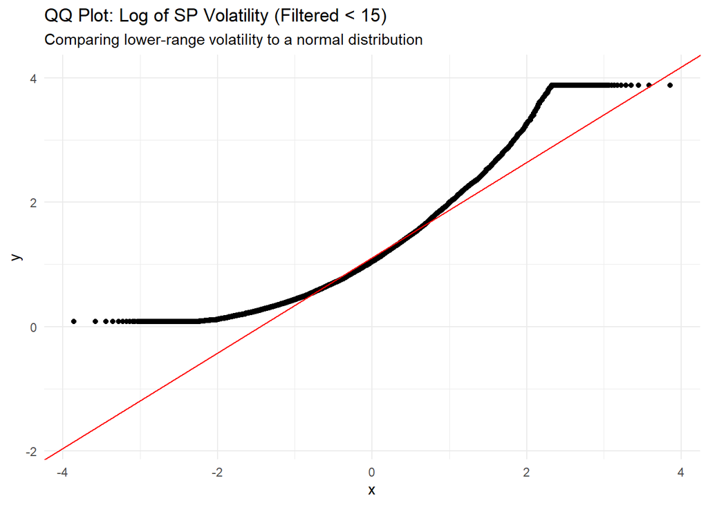

```r
# Filtering to < 15 to make the QQ plot readable for log_vol
vol_filtered_log <- subset(d501, `wins_log_vol` < 15)

ggplot(vol_filtered_log, aes(sample = `wins_log_vol`)) +
  stat_qq(na.rm = TRUE) +
  stat_qq_line(color = "red", na.rm = TRUE) +
  labs(title = "QQ Plot: Log of SP Volatility (Filtered < 15)",
       subtitle = "Comparing lower-range volatility to a normal distribution") +
  theme_minimal()
```

#also gonna re-run the histogram for the SP volatility

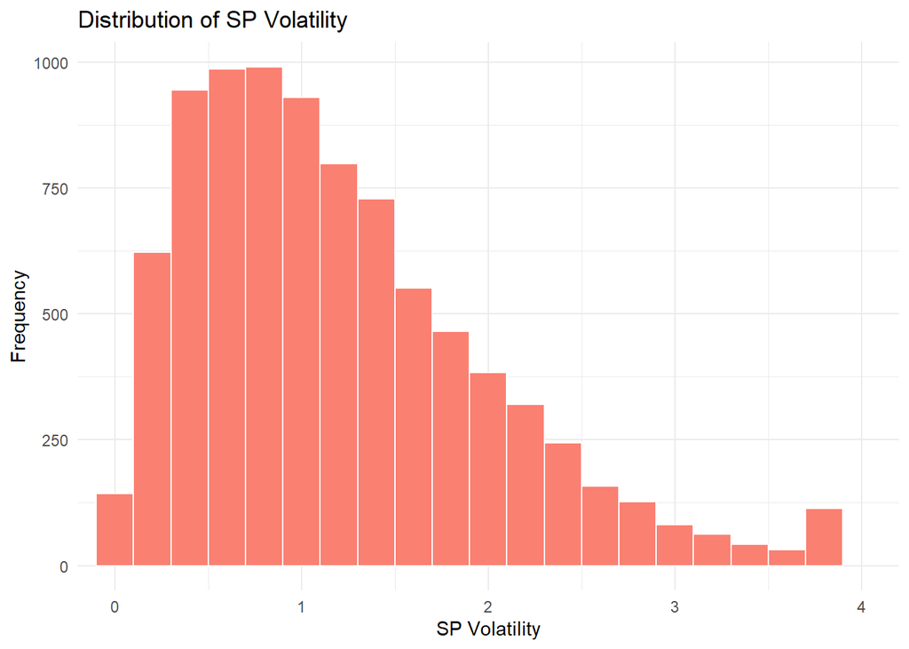

```r
ggplot(d501, aes(x = `wins_log_vol`)) +
  geom_histogram(fill = "salmon", color = "white", binwidth = 0.2, na.rm = TRUE) +
  coord_cartesian(xlim = c(0, 4)) +
  labs(title = "Distribution of SP Volatility",
       x = "SP Volatility",
       y = "Frequency") +
  theme_minimal()
```

#still need to do something about ESG momentum, taking the log is a bad idea, bc if we try log(x+1), logging the values between 0 anf 1 would create a negative spike, we get large negative numbers. Not good for RQ1 and RQ3 bc it would impact momentum.

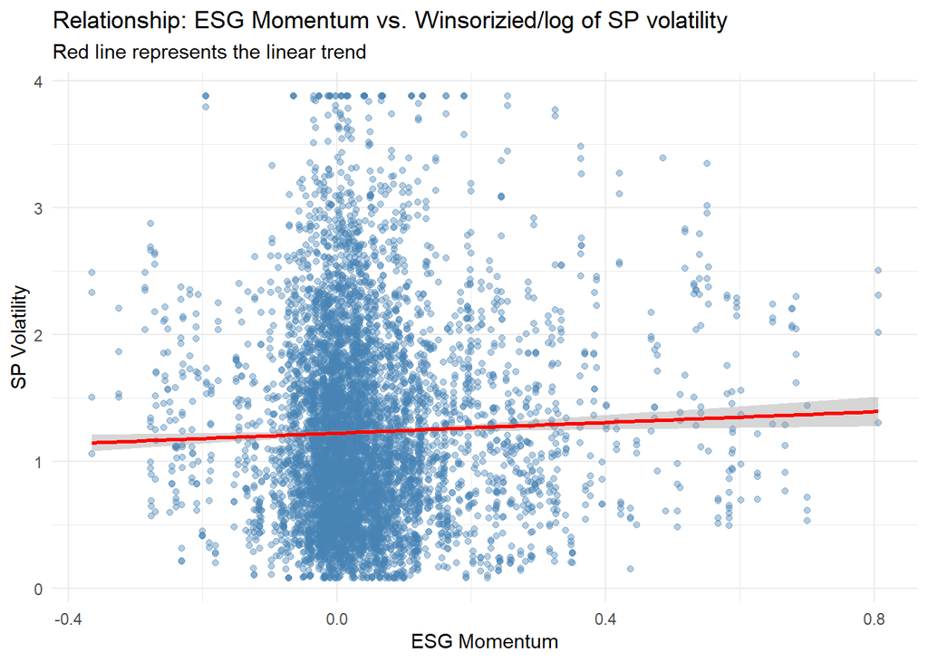

```r
ggplot(d501, aes(x = `ESG.Momentum`, y = `wins_log_vol`)) +
  geom_point(alpha = 0.4, color = "steelblue") +
  geom_smooth(method = "lm", color = "red", se = TRUE) + # Adds linear regression line
  labs(title = "Relationship: ESG Momentum vs. Winsorizied/log of SP volatility",
       subtitle = "Red line represents the linear trend",
       x = "ESG Momentum",
       y = "SP Volatility") +
  theme_minimal()
```

#alternative idea: Standardize ESG momentum (also called z-score transformation) centers our data so the mean is 0 and the standard deviation is 1 #would impact how we interpret our results, making them much more comparable #changes how we interpet the B-coefficents in our regression analysis! After standardizing we would say that “1 standard deviation increase in ESG momentum leads to an X% change in volatility” -> standard in finance, tells people how “typical” move in ESG performance (relative to other Canadian companies) impacts risk. #standarization does not change our p-value, if the relationship was singificant before it would still be signicint, only changes the scale of the slope #by dividing the SD we shrink the impact of those extreme momentum values that Winsorization may have missed.

#To ensure comparability across different ESG pillars and to mitigate the impact of right-skewed momentum distributions, we will standardized all ESG Momentum variables (mean = 0, SD = 1). Volatility was log-transformed and Winsorized at the 1% and 99% levels to achieve normality and handle extreme outliers

#trying to standarize! centers the data so the mean is 0 and the SD is 1. do this with the winzoriszed ESG so that we “clip” the outliers to a resonable level, and then we standardize, so that the SD is calucated based on a cleaner range

```r
d501$stand_esg_mom <- scale(d501$wins_esg_mom)
```

#check to see if it worked!! look at the new mean via histogram

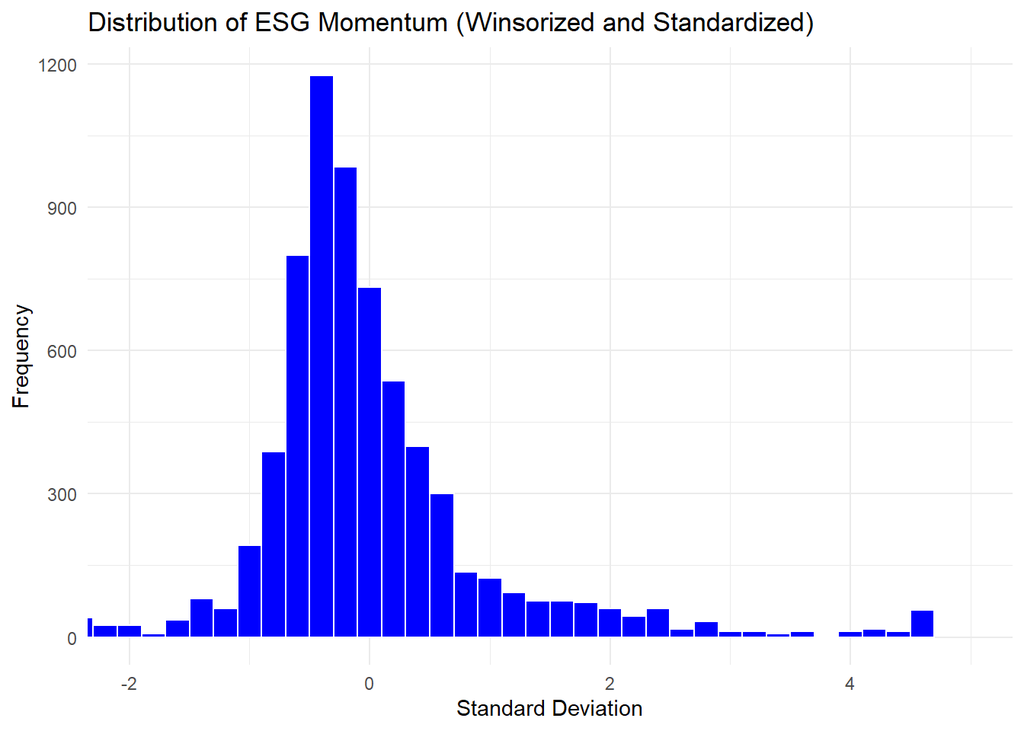

```r
ggplot(d501, aes(x = `stand_esg_mom`)) +
  geom_histogram(fill = "blue", color = "white", binwidth = 0.2, na.rm = TRUE) +
  coord_cartesian(xlim = c(-2, 5)) +
  labs(title = "Distribution of ESG Momentum (Winsorized and Standardized)",
       x = "Standard Deviation",
       y = "Frequency") +
  theme_minimal()
```

#This worked, the bulk of the data is centered around 0, and the x-axis is now the standard deviation #the reason it still looks skewed is that the standardication only changes the scale of the values not the shape of the distribution #should be fine for a regression bc we have capped the extreme outliers through winsorization and made the magnitude of the jumps statistically managable

#how are things looking now if we compare standaridzed ESG and the winsorized/log of SP volatility?

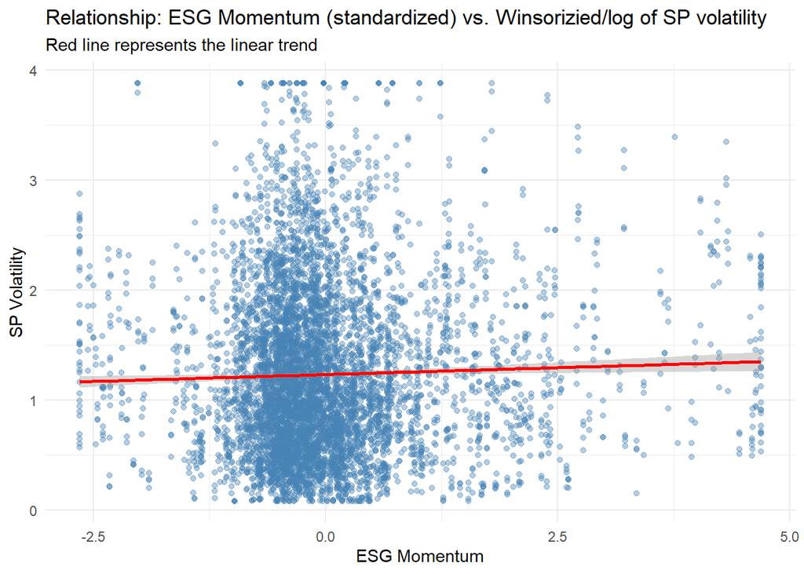

```r
ggplot(d501, aes(x = `stand_esg_mom`, y = `wins_log_vol`)) +
  geom_point(alpha = 0.4, color = "steelblue") +
  geom_smooth(method = "lm", color = "red", se = TRUE) + # Adds linear regression line
  labs(title = "Relationship: ESG Momentum (standardized) vs. Winsorizied/log of SP volatility",
       subtitle = "Red line represents the linear trend",
       x = "ESG Momentum",
       y = "SP Volatility") +
  theme_minimal()
```

#the red line is showing a slight upward slope from left to right, suggesting a positive correlation between ESG momentum and Volatility tends to increase slightly. in finance, it is expected that ESG scores lower risk, but I guess ESG momentum may be increasing risk in this case #we see a box shape, the straight horizontal line of dots near the top and a straight vertical line of dots at the right -> these are winsorized boundaries, instead of having a few extreme outliers pulling the red line way up or way out, those values have been capped. #interpret this with caution, we still need to control for the fama french factors!! they could explain some of this variance

#IMPORTANT: FOR THE REST OF THE ANALYSIS, WHEN USING ESG MOMENTUM USE stand_esg_mom (this variable has winsorizied ESG momentum conservatively and has standardizied it)

#time to winsorize and standardize the pillars!

#Enviroment

```r
#winsorize first
d501$wins_esg_mom_E <- DescTools::Winsorize(d501$ESG.Mom.Env, val = quantile(x= d501$ESG.Mom.Env, probs = c(0.005, 0.995), na.rm = TRUE))

#then standardize
d501$stand_esg_mom_E <- scale(d501$wins_esg_mom_E)
```

#look at it via histogram!

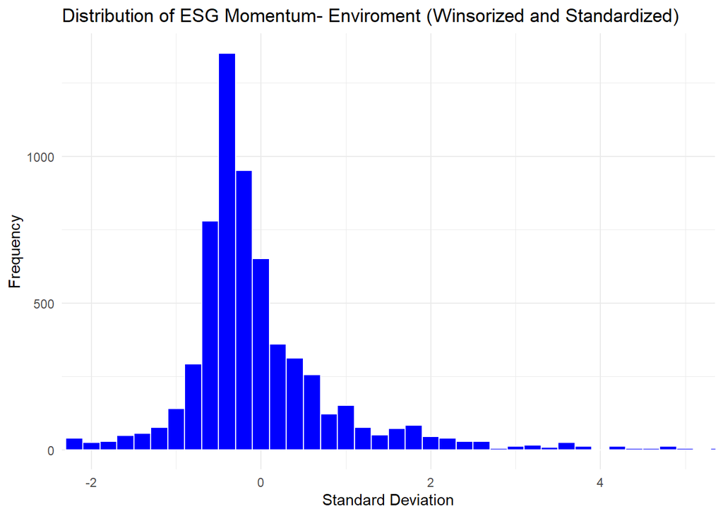

```r
ggplot(d501, aes(x = `stand_esg_mom_E`)) +
  geom_histogram(fill = "blue", color = "white", binwidth = 0.2, na.rm = TRUE) +
  coord_cartesian(xlim = c(-2, 5)) +
  labs(title = "Distribution of ESG Momentum- Enviroment (Winsorized and Standardized)",
       x = "Standard Deviation",
       y = "Frequency") +
  theme_minimal()
```

#success, this scale now shows the SD for the enviromental pillar! this means it has gathered most of the outliers and plotted it correctly. even tho the data is still right skewed it is much more compact than before!

#winsorize and standardize the social and governance pillar

```r
#winsorize first
d501$wins_esg_mom_S <- DescTools::Winsorize(d501$ESG.Mom...Social, val = quantile(x= d501$ESG.Mom...Social, probs = c(0.005, 0.995), na.rm = TRUE))
d501$wins_esg_mom_G <- DescTools::Winsorize(d501$ESG.Mom...Gov, val = quantile(x= d501$ESG.Mom...Gov, probs = c(0.005, 0.995), na.rm = TRUE))


#then standardize
d501$stand_esg_mom_S <- scale(d501$wins_esg_mom_S)
d501$stand_esg_mom_G <- scale(d501$wins_esg_mom_G)
```

#view this via histogram

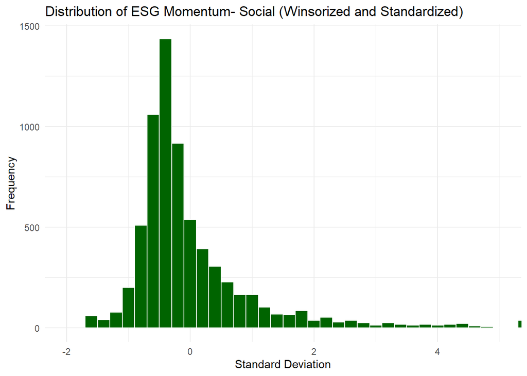

```r
ggplot(d501, aes(x = `stand_esg_mom_S`)) +
  geom_histogram(fill = "darkgreen", color = "white", binwidth = 0.2, na.rm = TRUE) +
  coord_cartesian(xlim = c(-2, 5)) +
  labs(title = "Distribution of ESG Momentum- Social (Winsorized and Standardized)",
       x = "Standard Deviation",
       y = "Frequency") +
  theme_minimal()
```

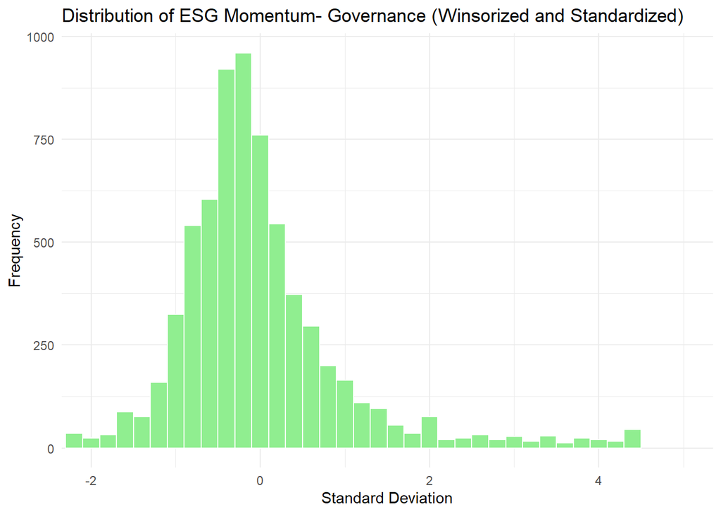

```r
ggplot(d501, aes(x = `stand_esg_mom_G`)) +
  geom_histogram(fill = "lightgreen", color = "white", binwidth = 0.2, na.rm = TRUE) +
  coord_cartesian(xlim = c(-2, 5)) +
  labs(title = "Distribution of ESG Momentum- Governance (Winsorized and Standardized)",
       x = "Standard Deviation",
       y = "Frequency") +
  theme_minimal()
```

#overall pretty successful, we still see that governance is more spread out that the social pillar!

#next step is to check the assumptions of a panel regression: linearity between the indepndent and dependent variables, strict ecogenity (the explanatory variables are uncorrelated with the error term), indepndent variables are not perfectly correlated with eachother (will need to check VIF), homoscedasticty (the error terms have constant variance and are not correlated over time for a given entitiy, no serial correlation)

#loading in the libraries we need

```r
library(dplyr)
library(zoo)
```

#IMPORTANT!!!!! NOW WE NEED TO BE ANALYSIZNG USING wins_log_vol -> THIS IS THE FOWARD LOOKING SP VOLATILITY VARIABLE THAT HAS BEEN TRANSFORMED! ##IMPORTANT!!! FOR ESG MOMENTUM, USE THE VARIABLE CALLED stand_esg_mom

#1. Check linarity using a partial residual plot, should be okay considering we already transformed the data but we should still check

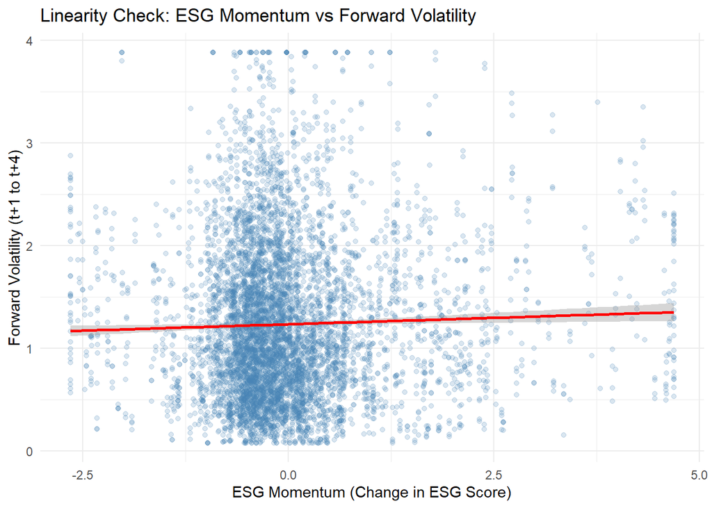

```r
library(ggplot2)

ggplot(d501, aes(x = `stand_esg_mom`, y = wins_log_vol)) +
  geom_point(alpha = 0.2, color = "steelblue") + # Alpha makes overlapping points visible
  geom_smooth(method = "lm", color = "red", se = TRUE) + # Adds the linear regression line
  labs(title = "Linearity Check: ESG Momentum vs Forward Volatility",
       x = "ESG Momentum (Change in ESG Score)",
       y = "Forward Volatility (t+1 to t+4)") +
  theme_minimal()
```

#2. Multicolinarity (checking using the VIF)

```r
library(car)
# Define a standard OLS model using our transformed variables for VIF check
fit_ols <- lm(wins_log_vol ~ stand_esg_mom + `Log.MCap` + `Book.to.Mkt` + ROA + `Asset.Growth`,
              data = d501)

# Run VIF
vif_results <- vif(fit_ols)
print(vif_results)
```

```
## stand_esg_mom      Log.MCap   Book.to.Mkt           ROA  Asset.Growth
##      1.022160      1.135939      1.118477      1.042832      1.011650
```

#all of these are less than 5, which means we are good!! No issues of multicolinarity!! a VIF = 1 means no correlation, VIF of 5 to 10 means high multicolinarity

#3. Testing for strict exogenity (variables should not be endogenous)! We do not want our variables to be correlated with the error term. common way to do this is to include a lead of the independent variable in the regression. hopefully we do not violate this lol #lead test-> checks if the future ESG score is caused by current volatility (reverse causality). would justify us using fixed effects

```r
#install.packages("fixest") install this package if you dont have it already
```

```r
library(fixest)

# We add lead(std_esg_mom, 1) to the regression
exog_check <- feols(wins_log_vol ~ stand_esg_mom + lead(stand_esg_mom, 1) +
                    wins_log_vol + `Log.MCap` + `Book.to.Mkt` + ROA + `Asset.Growth` |
                    Security + Index,
                    cluster = ~Security,
                    data = d501)
```

```
## NOTE: 2,160 observations removed because of NA values (LHS: 36, RHS: 2,160).
```

```r
summary(exog_check)
```

```
## OLS estimation, Dep. Var.: wins_log_vol
## Observations: 6,602
## Fixed-effects: Security: 252,  Index: 36
## Standard-errors: Clustered (Security)
##                         Estimate Std. Error   t value   Pr(>|t|)
## stand_esg_mom           0.000649   0.008941  0.072624 9.4216e-01
## lead(stand_esg_mom, 1)  0.009396   0.009539  0.985014 3.2557e-01
## Log.MCap                0.206533   0.031016  6.658830 1.7290e-10 ***
## Book.to.Mkt             0.012469   0.014082  0.885508 3.7673e-01
## ROA                    -0.001482   0.000811 -1.826213 6.9006e-02 .
## Asset.Growth            0.027342   0.020189  1.354297 1.7686e-01
## ---
## Signif. codes:  0 '***' 0.001 '**' 0.01 '*' 0.05 '.' 0.1 ' ' 1
## RMSE: 0.343057     Adj. R2: 0.78683
##                  Within R2: 0.045302
```

#wu-hausman -> checks if current ESG is correlated with current hidden factors (omitted variable bias). For this test you need to create an instrumental variable (correlated with IV and not correclated with the error term expcet through ESG momentum)

```r
# 1. Create the Instrument (Industry-Year Average ESG Momentum)
library(dplyr)
d501 <- d501 %>%
  group_by(INDUSTRY, Year) %>%
  mutate(peer_esg_mom = mean(stand_esg_mom, na.rm = TRUE)) %>%
  ungroup()

# 2. Run the IV Regression (2SLS)
# Syntax: feols(Y ~ Controls | Fixed Effects | Instrumented_Var ~ Instrument)
model_iv <- feols(wins_log_vol ~ Log.MCap + Book.to.Mkt + ROA + Asset.Growth |
                  INDUSTRY + Year |
                  stand_esg_mom ~ peer_esg_mom,
                  cluster = ~Security,
                  data = d501)
```

```
## NOTE: 2,034 observations removed because of NA values (LHS: 36, IV: 2,002/0).
```

```r
# 3. Get the Wu-Hausman Test
summary(model_iv, stage = 1:2)
```

```
## IV: First stage: stand_esg_mom
## TSLS estimation - Dep. Var.: stand_esg_mom
##                   Endo.    : stand_esg_mom
##                   Instr.   : peer_esg_mom
## First stage: Dep. Var.: stand_esg_mom
## Observations: 6,728
## Fixed-effects: INDUSTRY: 3,  Year: 9
## Standard-errors: Clustered (Security)
##               Estimate Std. Error   t value   Pr(>|t|)
## peer_esg_mom  1.036313   0.272799  3.798818 1.8246e-04 ***
## Log.MCap     -0.083749   0.016397 -5.107554 6.4607e-07 ***
## Book.to.Mkt  -0.033580   0.030850 -1.088481 2.7743e-01
## ROA          -0.002102   0.002401 -0.875304 3.8225e-01
## Asset.Growth  0.159711   0.070112  2.277945 2.3571e-02 *
## ---
## Signif. codes:  0 '***' 0.001 '**' 0.01 '*' 0.05 '.' 0.1 ' ' 1
## RMSE: 0.95988     Adj. R2: 0.076425
##                 Within R2: 0.029567
## F-test (1st stage): stat = 72.680, p < 2.2e-16, on 1 and 6,712 DoF.
##
## IV: Second stage
## TSLS estimation - Dep. Var.: wins_log_vol
##                   Endo.    : stand_esg_mom
##                   Instr.   : peer_esg_mom
## Second stage: Dep. Var.: wins_log_vol
## Observations: 6,728
## Fixed-effects: INDUSTRY: 3,  Year: 9
## Standard-errors: Clustered (Security)
##                    Estimate Std. Error   t value   Pr(>|t|)
## fit_stand_esg_mom  0.060905   0.103925  0.586049 5.5837e-01
## Log.MCap           0.191621   0.025222  7.597354 5.9887e-13 ***
## Book.to.Mkt       -0.028302   0.028468 -0.994182 3.2109e-01
## ROA                0.001957   0.001218  1.607157 1.0928e-01
## Asset.Growth       0.016849   0.043854  0.384211 7.0115e-01
## ---
## Signif. codes:  0 '***' 0.001 '**' 0.01 '*' 0.05 '.' 0.1 ' ' 1
## RMSE: 0.661619     Adj. R2: 0.23977
##                  Within R2: 0.165267
## F-test (1st stage), stand_esg_mom: stat = 72.68020, p < 2.2e-16 , on 1 and 6,712 DoF.
##                        Wu-Hausman: stat =  0.02926, p = 0.864192, on 1 and 6,711 DoF.
```

```r
fixest::fitstat(model_iv, ~ wh + ivf)
```

```
##                        Wu-Hausman: stat =  0.02926, p = 0.864192, on 1 and 6,711 DoF.
## F-test (1st stage), stand_esg_mom: stat = 72.68020, p < 2.2e-16 , on 1 and 6,712 DoF.
```

#the p-value for the fit is insignificant, this is good! We fail to reject Ho and we are justifyed in using the standard fixed effects model. this measn ESG momentum is not singificantly correlated with the error term, so fixed effects is consistent and more efficent

#4. Homoscedasicty (in financial data we almost always find heterosecdascity, different variances across firms), and serial correlation (volatility is sticky over time). if this is the case use the clustered standard errors (already wrote about this in the proposal)

```r
library(lmtest)

# 1. Fit our model
model_ols <- lm(wins_log_vol ~ stand_esg_mom + `Log.MCap` + `Book.to.Mkt` + ROA + `Asset.Growth`,
                data = d501)

# 2. Run the Breusch-Pagan test
# H0: Homoscedasticity (Variance is constant)
# H1: Heteroscedasticity (Variance changes with X)
bptest(model_ols)
```

```
##
##  studentized Breusch-Pagan test
##
## data:  model_ols
## BP = 172.81, df = 5, p-value < 2.2e-16
```

#we did expect to fail this test, and we did with a singificant p-value. again this is expected in panel data, so we do have heteroscedascity. this is very common for stock market data, means the “size” of our errors changes depending on the firm’s size, ESG score or volatility. This means our standard errors are biased. SOLUTION: we use the clustered standard errors (which we are already doing with the feols function and cluster = ~Security). this fixes our p-value of our coefficents.

```r
# Run the Fixed Effects Model
library(fixest)

# Final RQ1 Model
model_rq1_final <- feols(wins_log_vol ~ stand_esg_mom +
                         Log.MCap + Book.to.Mkt + ROA + Asset.Growth |
                         INDUSTRY + Year,
                         cluster = ~Security,           #Standard errors must be clustered
                         data = d501)
```

```
## NOTE: 2,034 observations removed because of NA values (LHS: 36, RHS: 2,002).
```

```r
summary(model_rq1_final)
```

```
## OLS estimation, Dep. Var.: wins_log_vol
## Observations: 6,728
## Fixed-effects: INDUSTRY: 3,  Year: 9
## Standard-errors: Clustered (Security)
##                Estimate Std. Error   t value   Pr(>|t|)
## stand_esg_mom  0.047152   0.013424  3.512527 5.2624e-04 ***
## Log.MCap       0.190477   0.023314  8.170166 1.5181e-14 ***
## Book.to.Mkt   -0.028760   0.028488 -1.009571 3.1367e-01
## ROA            0.001927   0.001182  1.631259 1.0409e-01
## Asset.Growth   0.019102   0.039874  0.479064 6.3231e-01
## ---
## Signif. codes:  0 '***' 0.001 '**' 0.01 '*' 0.05 '.' 0.1 ' ' 1
## RMSE: 0.661485     Adj. R2: 0.243287
##                  Within R2: 0.169128
```

#our results are statisticall singificant, with a p-value = 0.0005 which is lower than 0.05! our ESG momentum variable is now highly singnificant! #how to interpert this (remeber esg momentum is now standardized): for every 1 standard deviation increase in ESG momentu, the log if the forward looking volatility increased by 4.7%. We originally expected ESG momentum to act as a risk mitigator (based on literature from the US markets), but here our coefficent is positive, suggesting that firms with high ESG momentum are seeing higher volatility in this specific window. We will need to discuss why we may think this is

#log.mcap is our strongest control, shows that as firm size increases, the model predicted volatility also increases here.

#book to mkt, ROA and assest growth all have insignificant p-values, meaning they are not statistically significant in this specific model, not helping or hurting our prediction

#summary of the model: fixed effects for industry type and the year, not interested in seeing the effect of industry for this RQ, future analysis will look at this more closely. this result is not just a result of a “bad year” or a “volatile industry #we also have a standard clustered error using the firms (security) means the model accounts for the fact that observations from the same company are related over time. This makes our p-values much more”honest” and reliable. #lots of observations which means we have high statistical power!

#looking at R-squared: adjusted R2 = our model explains 24.3% of the total variation in stock volatility. this is good! Within R2 = tells us that 16.9% of the variation within industries and years is explained by our variables

#next steps: the fact that stand_esg_mom and Log.MCap are both positive is surprising! maybe this is explaining by the company size or the indsutry type, running analysis for RQ2 and RQ3!

#Re-running original regression, not using transformed variables to get a sense of the “baseline relationship”. Important for our report

```r
# Run the Fixed Effects Model
library(fixest)

# Final RQ1 Model
model_rq1_final <- feols(SP.Volatility ~ ESG.Momentum +  #important difference: using original variables
                         Log.MCap + Book.to.Mkt + ROA + Asset.Growth |
                         INDUSTRY + Year,
                         cluster = ~Security,
                         data = d501)
```

```
## NOTE: 2,034 observations removed because of NA values (LHS: 36, RHS: 2,002).
```

```r
summary(model_rq1_final)
```

```
## OLS estimation, Dep. Var.: SP.Volatility
## Observations: 6,728
## Fixed-effects: INDUSTRY: 3,  Year: 9
## Standard-errors: Clustered (Security)
##               Estimate Std. Error   t value Pr(>|t|)
## ESG.Momentum  3.720549   1.520691  2.446617 0.015107 *
## Log.MCap      1.932090   0.888688  2.174092 0.030633 *
## Book.to.Mkt  -0.246552   0.545029 -0.452364 0.651397
## ROA           0.016769   0.015323  1.094431 0.274815
## Asset.Growth  0.795215   0.699299  1.137160 0.256556
## ---
## Signif. codes:  0 '***' 0.001 '**' 0.01 '*' 0.05 '.' 0.1 ' ' 1
## RMSE: 17.4     Adj. R2: 0.043945
##              Within R2: 0.028964
```

```r
#install.packages("performance") #install if you don't have it already
#install.packages("see")
library(performance)
# This will check normality, heteroscedasticity, and outliers all at once
check_model(model_rq1_final, check = c("normality", "homogeneity", "outliers"))
```

```
## Converting missing values (`NA`) into regular values currently not
##   possible for variables of class `NULL`.
```

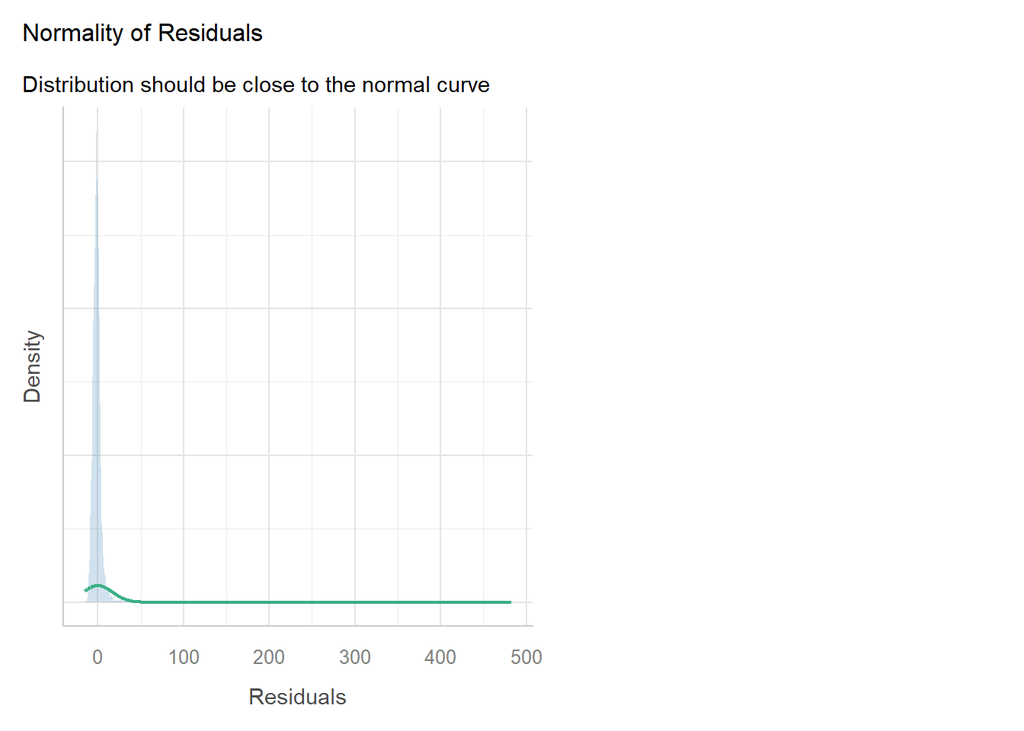

#this is very bad, extremely right skewed, what we observed earlier